# Ranking with TPM vs Count inputs with or without shrinkage

Mira Sohn

## Raw data

#### - **Link**: https://www.ncbi.nlm.nih.gov/geo/query/acc.cgi?acc=GSE157852

#### - **Study aim**: Reveal neurological complications in patients with COVID-19

#### - **Study summary**: Human Pluripotent Stem Cell-Derived Neural Cells and Brain Organoids were infected with SARS-CoV-2 for 72hrs and analyzed with bulk RNA-seq.

#### - Samples: Mock- or SARS-CoV-2-infected neuronal cells

## Loading packages

```r
library(data.table)
library(rmarkdown)
library(AnnotationHub)
library(tidyverse)
library(tximport)
library(ggplot2)
library(DESeq2)
library(UpSetR)
library(apeglm)
library(ashr)
```

## Setting AnnotationHub

```r
AnnotationSpecies <- "Homo sapiens"  # Assign your species
ah <- AnnotationHub(hub=getAnnotationHubOption("URL"))   # Bring annotation DB
```

## Running AnnotationHub

```r
ahQuery <- query(ah, c("OrgDb", AnnotationSpecies))      # Filter annotation of interest

if (length(ahQuery) == 1) {
    DBName <- names(ahQuery)
} else if (length(ahQuery) > 1) {
               DBName <- names(ahQuery)[1]
} else {
    print("You don't have a valid DB")
    rmarkdown::render()
}

AnnoDb <- ah[[DBName]] # Store into an OrgDb object

# Explore your OrgDb object with following accessors:
# columns(AnnpDb)
# keytypes(AnnoDb)
# keys(AnnoDb, keytype=..)
# select(AnnoDb, keys=.., columns=.., keytype=...)
AnnoKey <- keys(AnnoDb, keytype="ENSEMBLTRANS")

# Note: Annotation has to be done with not genome but transcripts
AnnoDb <- select(AnnoDb,
                 AnnoKey,
                 keytype="ENSEMBLTRANS",
                 columns="SYMBOL")
```

## Checking out the AnnotationHub output

```r
# Check if your AnnoDb has been extracted and saved correctely
class(AnnoDb)
```

```
## [1] "data.frame"
```

```r
head(AnnoDb)
```

```
##      ENSEMBLTRANS SYMBOL
## 1 ENST00000543404  A2MP1
## 2 ENST00000566278  A2MP1
## 3 ENST00000545343  A2MP1
## 4 ENST00000544183  A2MP1
## 5 ENST00000286479   NAT2
## 6 ENST00000520116   NAT2
```

## Defining file name and path for .sf files

#### .sf files have been created from fastq data by salmon

```r
# This code chunk needs to be revised by yourself

# Define sample names
SampleNames <-  c("Mock_72hpi_S1",
                 "Mock_72hpi_S2",
                 "Mock_72hpi_S3",
                 "SARS-CoV-2_72hpi_S7",
                 "SARS-CoV-2_72hpi_S8",
                 "SARS-CoV-2_72hpi_S9")

# Define group level
GroupLevel <- c("Mock", "COVID")

# Define contrast for DE analysis
Contrast <- c("Group", "COVID", "Mock")

# Define a vector for comparing TPM vs Counts effect
TvC <- c("TPM", "Counts")

# Define .sf file path
sf <- c(paste0(SampleNames,
               ".salmon_quant/quant.sf"))

# Define sample groups
group <- c(rep("Mock", 3), rep("COVID", 3))

# Create metadata
metadata <- data.frame(Sample=factor(SampleNames, levels=SampleNames),
                       Group=factor(group, levels=GroupLevel),
                       Path=sf)

rownames(metadata) <- SampleNames

# Explore the metadata
print(metadata)
```

```
##                                  Sample Group
## Mock_72hpi_S1             Mock_72hpi_S1  Mock
## Mock_72hpi_S2             Mock_72hpi_S2  Mock
## Mock_72hpi_S3             Mock_72hpi_S3  Mock
## SARS-CoV-2_72hpi_S7 SARS-CoV-2_72hpi_S7 COVID
## SARS-CoV-2_72hpi_S8 SARS-CoV-2_72hpi_S8 COVID
## SARS-CoV-2_72hpi_S9 SARS-CoV-2_72hpi_S9 COVID
##                                                          Path
## Mock_72hpi_S1             Mock_72hpi_S1.salmon_quant/quant.sf
## Mock_72hpi_S2             Mock_72hpi_S2.salmon_quant/quant.sf
## Mock_72hpi_S3             Mock_72hpi_S3.salmon_quant/quant.sf
## SARS-CoV-2_72hpi_S7 SARS-CoV-2_72hpi_S7.salmon_quant/quant.sf
## SARS-CoV-2_72hpi_S8 SARS-CoV-2_72hpi_S8.salmon_quant/quant.sf
## SARS-CoV-2_72hpi_S9 SARS-CoV-2_72hpi_S9.salmon_quant/quant.sf
```

## Converting .sf files to txi list

#### - txi_tpm: stores **TPM** with the argument **“countsFromAbundance=”lengthScaledTPM"**

#### - txi_counts: stores **original counts**

#### - Despite that the TPM matrix is not recommended as an input for DE analysis due to the fact that it doesn’t account gene length, TPM stored in a tximport (by **tximport(…, countsFromAbundance=“lengthScaledTPM”)**) can be used for DE analysis by being inputted with the **DESeqDataSetFromTximport()** funtion in DESeq2 workflow as the gene length is automatically adjusted by DESeqDataSetFromTximport().

#### - In this project, two txi objects were created with or without the countsFromAbundance=“lengthScaledTPM” argument and compared in downstream DE analysis.

#### - If you don’t want gene-level summarization, set **txOut=TRUE**.

#### - References: [**tximport doc**](https://bioconductor.riken.jp/packages/3.4/bioc/vignettes/tximport/inst/doc/tximport.html), [**DESeq2 doc “Why unnormalized counts?”**](https://www.bioconductor.org/packages/devel/bioc/vignettes/DESeq2/inst/doc/DESeq2.html#why-un-normalized-counts), [**Soneson et al. 2016**](https://www.ncbi.nlm.nih.gov/pmc/articles/PMC4712774/), [**Developer Dr. Love’s comment**](https://support.bioconductor.org/p/84059/), [**Harvard Chan Bioinformatics Core workshop**](https://github.com/hbctraining/DGE_workshop_salmon_online/blob/master/lessons/02_DGE_count_normalization.md)

```r
# Assign sample names to the input (.sf) file path
names(sf) <- SampleNames

# Run tximport
# tpm vs original counts
# input sf: a factor of all .sf files' path
txi_tpm <- tximport(sf,
                    type="salmon",
                    tx2gene=AnnoDb,
                    countsFromAbundance="lengthScaledTPM", # Extracts TPM
                    ignoreTxVersion=T)

txi_counts <- tximport(sf,
                    type="salmon",
                    tx2gene=AnnoDb,
                    ignoreTxVersion=T)
```

## Exploring the txi outputs

```r
# tpm
head(txi_tpm$counts)
```

```
##         Mock_72hpi_S1 Mock_72hpi_S2 Mock_72hpi_S3 SARS-CoV-2_72hpi_S7
## A2MP1        5.077648      5.609035     0.8096504             0.00000
## A3GALT2      0.000000      0.000000     0.0000000             0.00000
## A4GNT        0.000000      2.974963     1.0038198             0.00000
## AACSP1      14.891510     19.954031     9.2490944            19.26746
## AADACL2      0.000000      0.000000     0.0000000             0.00000
## AADACL4      1.013374      0.000000     2.0033163             0.00000
##         SARS-CoV-2_72hpi_S8 SARS-CoV-2_72hpi_S9
## A2MP1               0.00000           7.1022218
## A3GALT2             0.00000           0.0000000
## A4GNT               0.00000           0.9959273
## AACSP1             17.46992           4.5607796
## AADACL2             0.00000           0.0000000
## AADACL4             1.98163           0.0000000
```

```r
dim(txi_tpm$counts)
```

```
## [1] 12202     6
```

```r
# counts
head(txi_counts$counts)
```

```
##         Mock_72hpi_S1 Mock_72hpi_S2 Mock_72hpi_S3 SARS-CoV-2_72hpi_S7
## A2MP1           6.186             7             1                   0
## A3GALT2         0.000             0             0                   0
## A4GNT           0.000             3             1                   0
## AACSP1         16.000            22            10                  21
## AADACL2         0.000             0             0                   0
## AADACL4         1.000             0             2                   0
##         SARS-CoV-2_72hpi_S8 SARS-CoV-2_72hpi_S9
## A2MP1                     0                   3
## A3GALT2                   0                   0
## A4GNT                     0                   1
## AACSP1                   10                   5
## AADACL2                   0                   0
## AADACL4                   2                   0
```

```r
dim(txi_counts$counts)
```

```
## [1] 12202     6
```

## Creating DESeq objects from txi and VST

#### - Note: The tximport-to-DESeq2 approach uses estimated gene counts from the transcript abundance quantifiers, but not normalized counts.

#### - The **DESeqDataSetFromTximport()** function generated an DESeq object (aka **dds**) with the **txi input**.

#### - References: [**DESeq2 doc “Transcript abundance files”**](https://www.bioconductor.org/packages/devel/bioc/vignettes/DESeq2/inst/doc/DESeq2.html#tximport), [**DESeq2 doc “Variance stabilizing transformation”**](https://www.bioconductor.org/packages/devel/bioc/vignettes/DESeq2/inst/doc/DESeq2.html#variance-stabilizing-transformation)

```r
# Initialize a list storing dds object
desList <- list()

for (x in TvC) {

    if (x == TvC[1]) {

        desList[[x]] <- DESeqDataSetFromTximport(txi_tpm,
                                    colData=metadata,
                                    design=~Group)
    } else {

        desList[[x]] <- DESeqDataSetFromTximport(txi_counts,
                                    colData=metadata,
                                    design=~Group)

    }
}

# Exploring created dds
# TPM
desList[[TvC[1]]]
```

```
## class: DESeqDataSet
## dim: 12202 6
## metadata(1): version
## assays(1): counts
## rownames(12202): A2MP1 A3GALT2 ... ZXDB ZYXP1
## rowData names(0):
## colnames(6): Mock_72hpi_S1 Mock_72hpi_S2 ... SARS-CoV-2_72hpi_S8
##   SARS-CoV-2_72hpi_S9
## colData names(3): Sample Group Path
```

```r
head(counts(desList[[TvC[1]]]))
```

```
##         Mock_72hpi_S1 Mock_72hpi_S2 Mock_72hpi_S3 SARS-CoV-2_72hpi_S7
## A2MP1               5             6             1                   0
## A3GALT2             0             0             0                   0
## A4GNT               0             3             1                   0
## AACSP1             15            20             9                  19
## AADACL2             0             0             0                   0
## AADACL4             1             0             2                   0
##         SARS-CoV-2_72hpi_S8 SARS-CoV-2_72hpi_S9
## A2MP1                     0                   7
## A3GALT2                   0                   0
## A4GNT                     0                   1
## AACSP1                   17                   5
## AADACL2                   0                   0
## AADACL4                   2                   0
```

```r
# Counts
desList[[TvC[2]]]
```

```
## class: DESeqDataSet
## dim: 12202 6
## metadata(1): version
## assays(2): counts avgTxLength
## rownames(12202): A2MP1 A3GALT2 ... ZXDB ZYXP1
## rowData names(0):
## colnames(6): Mock_72hpi_S1 Mock_72hpi_S2 ... SARS-CoV-2_72hpi_S8
##   SARS-CoV-2_72hpi_S9
## colData names(3): Sample Group Path
```

```r
head(counts(desList[[TvC[2]]]))
```

```
##         Mock_72hpi_S1 Mock_72hpi_S2 Mock_72hpi_S3 SARS-CoV-2_72hpi_S7
## A2MP1               6             7             1                   0
## A3GALT2             0             0             0                   0
## A4GNT               0             3             1                   0
## AACSP1             16            22            10                  21
## AADACL2             0             0             0                   0
## AADACL4             1             0             2                   0
##         SARS-CoV-2_72hpi_S8 SARS-CoV-2_72hpi_S9
## A2MP1                     0                   3
## A3GALT2                   0                   0
## A4GNT                     0                   1
## AACSP1                   10                   5
## AADACL2                   0                   0
## AADACL4                   2                   0
```

## Estimating size factors, dispersions, and conducting Wald Test

#### - **Dispersion** is calculated as a **measure of variation** instead of variance since variance gets larger when gene expression gets higher.

#### - **Wald test** is the default setting of DESeq2 which tests null hypothesis between **two groups**. You should use **Likelihood ratio test (LRT)** when comparing **more than two groups**.

#### - Messages when “Counts <- DESeqPrep_fn(Counts)” was run:

using **‘avgTxLength’** from assays(dds), correcting for library size gene-wise dispersion estimates mean-dispersion relationship final dispersion estimates

#### - References: [**Harvard Chan Bioinformatics Core workshop I**](https://github.com/hbctraining/DGE_workshop_salmon_online/blob/master/lessons/05b_wald_test_results.md), [**Harvard Chan Bioinformatics Core workshop II**](https://github.com/hbctraining/DGE_workshop_salmon_online/blob/master/lessons/05a_hypothesis_testing.md), [**Harvard Chan Bioinformatics Core workshop III**](https://github.com/hbctraining/DGE_workshop_salmon_online/blob/master/lessons/04b_DGE_DESeq2_analysis.md), [**DESeq2 "Wald test indivisual steps**](https://www.bioconductor.org/packages/devel/bioc/vignettes/DESeq2/inst/doc/DESeq2.html#wald-test-individual-steps), [**DESeq2 doc “Likelihood ratio test”**](https://www.bioconductor.org/packages/devel/bioc/vignettes/DESeq2/inst/doc/DESeq2.html#likelihood-ratio-test)

```r
# Update dds

for (x in TvC) {

    desList[[x]] <- estimateSizeFactors(desList[[x]])
    desList[[x]] <- estimateDispersions(desList[[x]])
    desList[[x]] <- nbinomWaldTest(desList[[x]])
}

# Explore the updates
desList
```

```
## $TPM
## class: DESeqDataSet
## dim: 12202 6
## metadata(1): version
## assays(4): counts mu H cooks
## rownames(12202): A2MP1 A3GALT2 ... ZXDB ZYXP1
## rowData names(22): baseMean baseVar ... deviance maxCooks
## colnames(6): Mock_72hpi_S1 Mock_72hpi_S2 ... SARS-CoV-2_72hpi_S8
##   SARS-CoV-2_72hpi_S9
## colData names(4): Sample Group Path sizeFactor
##
## $Counts
## class: DESeqDataSet
## dim: 12202 6
## metadata(1): version
## assays(6): counts avgTxLength ... H cooks
## rownames(12202): A2MP1 A3GALT2 ... ZXDB ZYXP1
## rowData names(22): baseMean baseVar ... deviance maxCooks
## colnames(6): Mock_72hpi_S1 Mock_72hpi_S2 ... SARS-CoV-2_72hpi_S8
##   SARS-CoV-2_72hpi_S9
## colData names(3): Sample Group Path
```

## Running DE analysis with or without shrinkage

```r
# Create a list for TPM and Counts dds
ddsList <- desList  # DE without shrinkage
normal.ddsList <- desList    # DE with "normal" shrinkage
ape.ddsList <- desList       # DE with "apeglm" shrinkage
ash.ddsList <- desList       # DE with "ashr" shrinkage

for (x in TvC) {

    # Run DESeq()
    ddsList[[x]] <- DESeq(desList[[x]])
    print(resultsNames(ddsList[[x]]))

    normal.ddsList[[x]] <- lfcShrink(ddsList[[x]],
                                contrast=Contrast,
                                type="normal")

    ape.ddsList[[x]] <- lfcShrink(ddsList[[x]],
                             coef=resultsNames(ddsList[[x]])[2],
                             type="apeglm")

    ash.ddsList[[x]] <- lfcShrink(ddsList[[x]],
                             coef=resultsNames(ddsList[[x]])[2],
                             type="ashr")

}
```

```
## [1] "Intercept"           "Group_COVID_vs_Mock"
## [1] "Intercept"           "Group_COVID_vs_Mock"
```

```r
# Combine every ddsList into a list
all.ddsList <- list(ddsList, normal.ddsList, ape.ddsList, ash.ddsList)
shrinkage <- c("None", "Normal", "Apeglm", "Ashr")
names(all.ddsList) <- shrinkage
```

## Extracting DE results with or without shrinkage

#### - The **alpha** denotes threshold of **false discovery rate (FDR)** assigned by users.

#### - In this analysis, the alpha is set to **0.1**

```r
# Set FDR threshold
alpha=0.1

# FDR threshold vector
FDRv=c("< 0.1", "> 0.1")

# Initialize lists of result tables
all.resList <- all.ddsList

# Set a function cleaning table
Sig.fn <- function(df, Input) {

    df <- df %>%
        rownames_to_column(var="Gene") %>%
        mutate(FDR=ifelse(padj < 0.1 & !is.na(padj),
                                   FDRv[1],
                                   FDRv[2]),
               Input=Input)
    return(df)
}




for (i in shrinkage) {

    if (i == "None") {

        for (x in TvC) {

        # Extract data frames from unshrunken lfc & clean data
        all.resList[[i]][[x]] <- as.data.frame(results(all.ddsList[[i]][[x]],
                                                       contrast=Contrast,
                                                       alpha=alpha)) %>%
        Sig.fn(x)

         }
    } else {

        # Extract data frames from shrunken lfc & clean data
        for (x in TvC) {

            all.resList[[i]][[x]] <- as.data.frame(all.ddsList[[i]][[x]]) %>%
                Sig.fn(x)


        }
    }
}





# Explore the results
summary(all.resList)
```

```
##        Length Class  Mode
## None   2      -none- list
## Normal 2      -none- list
## Apeglm 2      -none- list
## Ashr   2      -none- list
```

```r
head(all.resList[[1]][['TPM']])
```

```
##      Gene   baseMean log2FoldChange     lfcSE       stat    pvalue      padj
## 1   A2MP1  3.0525639    -0.71117275 1.7535703 -0.4055570 0.6850681        NA
## 2 A3GALT2  0.0000000             NA        NA         NA        NA        NA
## 3   A4GNT  0.8296737    -1.91297083 3.0641144 -0.6243144 0.5324211        NA
## 4  AACSP1 13.9670247    -0.07686924 0.7514137 -0.1022995 0.9185190 0.9811568
## 5 AADACL2  0.0000000             NA        NA         NA        NA        NA
## 6 AADACL4  0.9621048    -0.34400388 2.9069797 -0.1183372 0.9058005        NA
##     FDR Input
## 1 > 0.1   TPM
## 2 > 0.1   TPM
## 3 > 0.1   TPM
## 4 > 0.1   TPM
## 5 > 0.1   TPM
## 6 > 0.1   TPM
```

```r
head(all.resList[[1]][['Counts']])
```

```
##      Gene   baseMean log2FoldChange     lfcSE       stat    pvalue      padj
## 1   A2MP1  2.8317018     -0.8410796 1.8117650 -0.4642322 0.6424814        NA
## 2 A3GALT2  0.0000000             NA        NA         NA        NA        NA
## 3   A4GNT  0.8395428     -1.9116000 3.0121489 -0.6346300 0.5256698        NA
## 4  AACSP1 13.9323130     -0.1237197 0.7552029 -0.1638231 0.8698704 0.9661114
## 5 AADACL2  0.0000000             NA        NA         NA        NA        NA
## 6 AADACL4  0.9757540     -0.3681081 2.8561649 -0.1288819 0.8974511        NA
##     FDR  Input
## 1 > 0.1 Counts
## 2 > 0.1 Counts
## 3 > 0.1 Counts
## 4 > 0.1 Counts
## 5 > 0.1 Counts
## 6 > 0.1 Counts
```

```r
head(all.resList[[2]][['TPM']])
```

```
##      Gene   baseMean log2FoldChange     lfcSE       stat    pvalue      padj
## 1   A2MP1  3.0525639    -0.13588716 0.3372049 -0.4055570 0.6850681        NA
## 2 A3GALT2  0.0000000             NA        NA         NA        NA        NA
## 3   A4GNT  0.8296737    -0.12996851 0.2230905 -0.6243144 0.5324211        NA
## 4  AACSP1 13.9670247    -0.04328458 0.4236828 -0.1022995 0.9185190 0.9811568
## 5 AADACL2  0.0000000             NA        NA         NA        NA        NA
## 6 AADACL4  0.9621048    -0.02659239 0.2313921 -0.1183372 0.9058005        NA
##     FDR Input
## 1 > 0.1   TPM
## 2 > 0.1   TPM
## 3 > 0.1   TPM
## 4 > 0.1   TPM
## 5 > 0.1   TPM
## 6 > 0.1   TPM
```

```r
head(all.resList[[2]][['Counts']])
```

```
##      Gene   baseMean log2FoldChange     lfcSE       stat    pvalue      padj
## 1   A2MP1  2.8317018    -0.14479543 0.3333802 -0.4642322 0.6424814        NA
## 2 A3GALT2  0.0000000             NA        NA         NA        NA        NA
## 3   A4GNT  0.8395428    -0.13464596 0.2270494 -0.6346300 0.5256698        NA
## 4  AACSP1 13.9323130    -0.06903748 0.4245107 -0.1638231 0.8698704 0.9661114
## 5 AADACL2  0.0000000             NA        NA         NA        NA        NA
## 6 AADACL4  0.9757540    -0.02945511 0.2355359 -0.1288819 0.8974511        NA
##     FDR  Input
## 1 > 0.1 Counts
## 2 > 0.1 Counts
## 3 > 0.1 Counts
## 4 > 0.1 Counts
## 5 > 0.1 Counts
## 6 > 0.1 Counts
```

## Exploring mean-difference relationship with MA plots

#### - **x-axis**: expression level (baseMean))

#### - **y-axis**: fold change (log2FoldChange)

#### - **Red dashed lines**: log2FoldChange = -1 and 1

#### - Reference: [**DESeq2 doc “MA-plot”**](https://www.bioconductor.org/packages/devel/bioc/vignettes/DESeq2/inst/doc/DESeq2.html#ma-plot)

[output not shown]

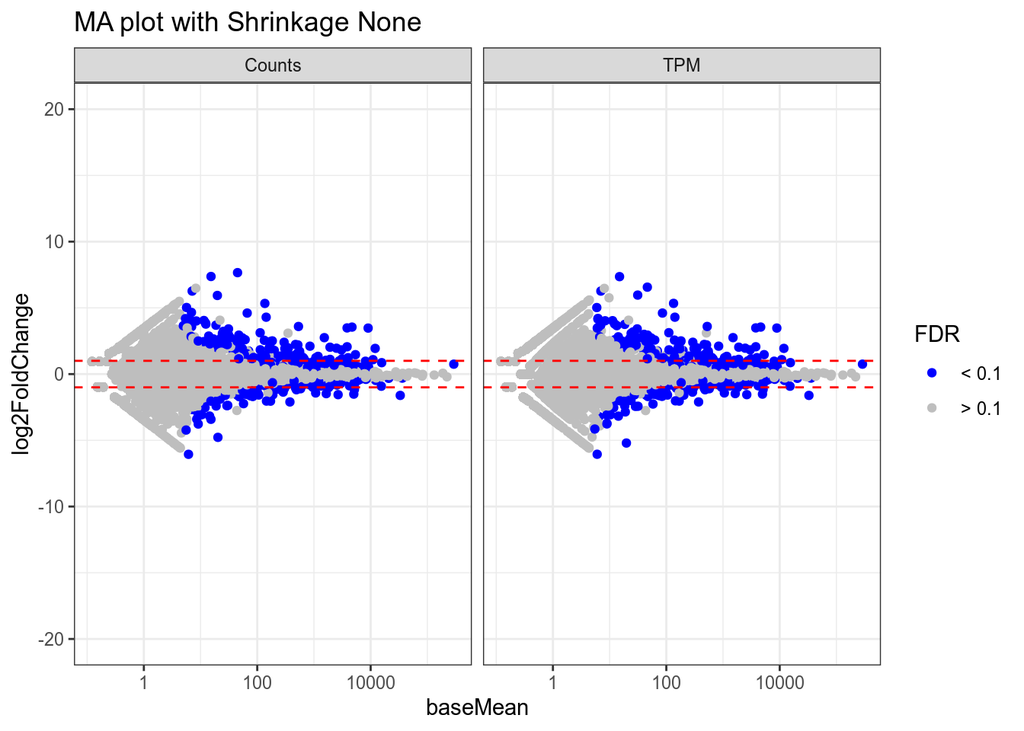

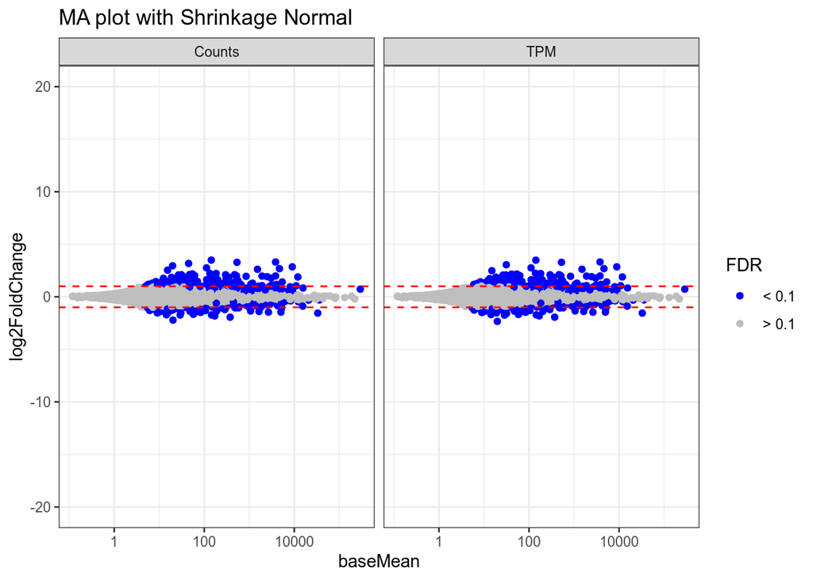

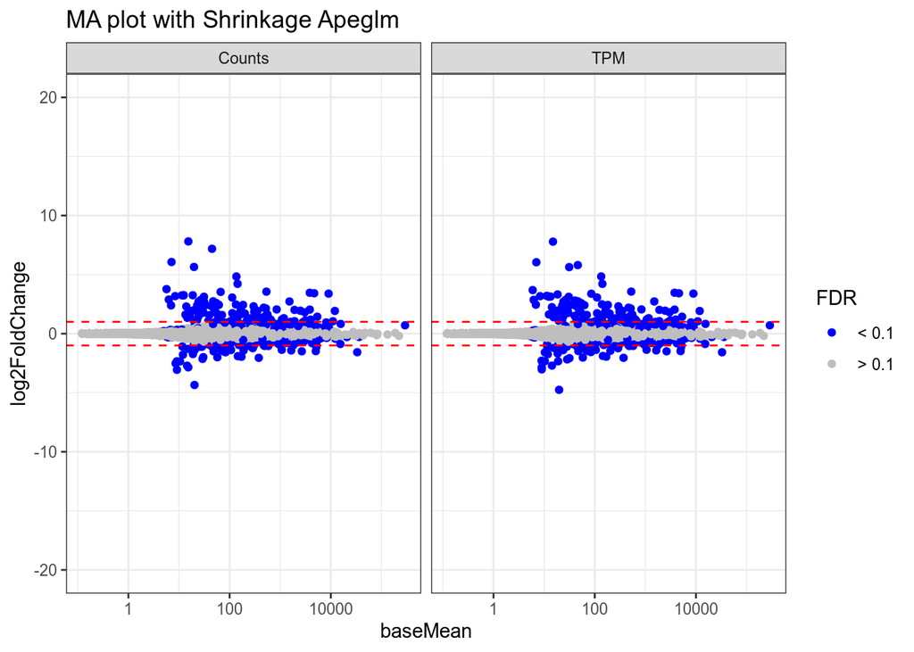

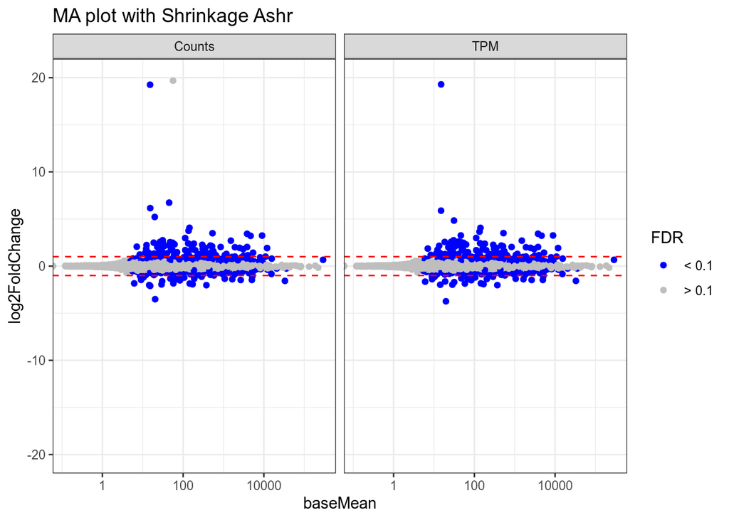

```r
# Set ylim: has to adjusted by users depending on data
yl <- c(-20, 20)

# Set min log2 fold change of interest
mLog <- c(-1, 1)

# Initialize a list storing MA plots
MAList <- ddsList


# Create MA plots

for (i in shrinkage) {

    both.df <- rbind(all.resList[[i]][[TvC[1]]],
                     all.resList[[i]][[TvC[2]]])

    MAList[[i]] <- ggplot(both.df,
                              aes(x=baseMean, y=log2FoldChange, color=FDR))  +geom_point() + scale_x_log10() + facet_grid(~Input) +
                                   theme_bw() +
                                   scale_color_manual(values=c("blue", "grey")) +
                                   ggtitle(paste("MA plot with Shrinkage", i)) +
                                   ylim(yl[1], yl[2]) +
                                   geom_hline(yintercept=c(mLog[1], mLog[2]), linetype="dashed", color="red")

}



# Print MA plots
MAList
```

## Exploring distribution of log2FoldChange by input type

#### - **y-axis**: number of genes

[output not shown]

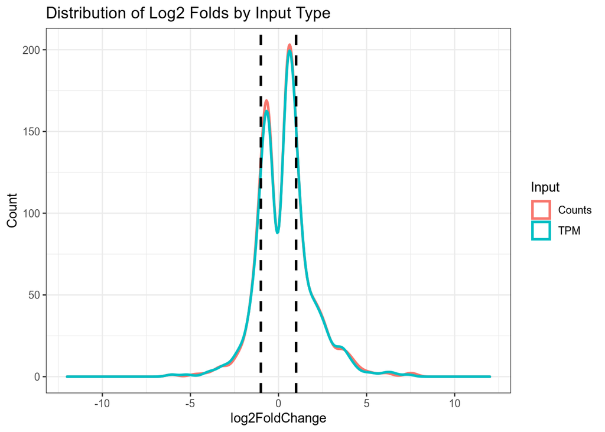

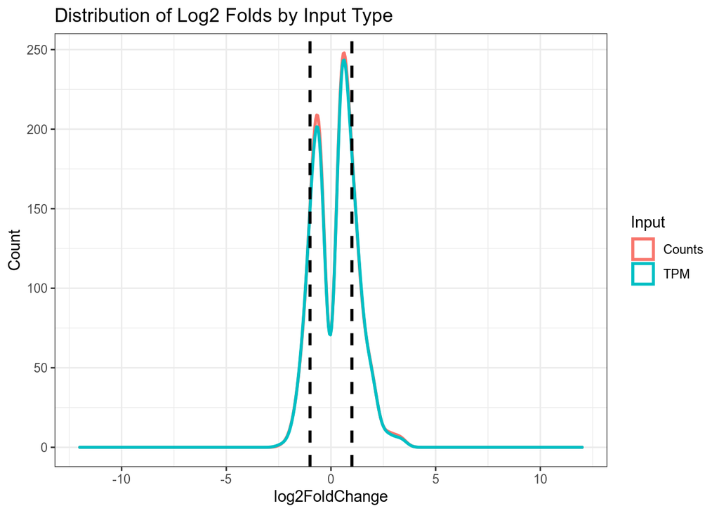

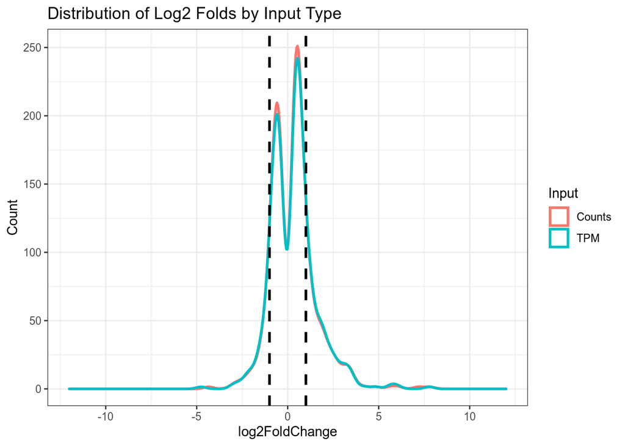

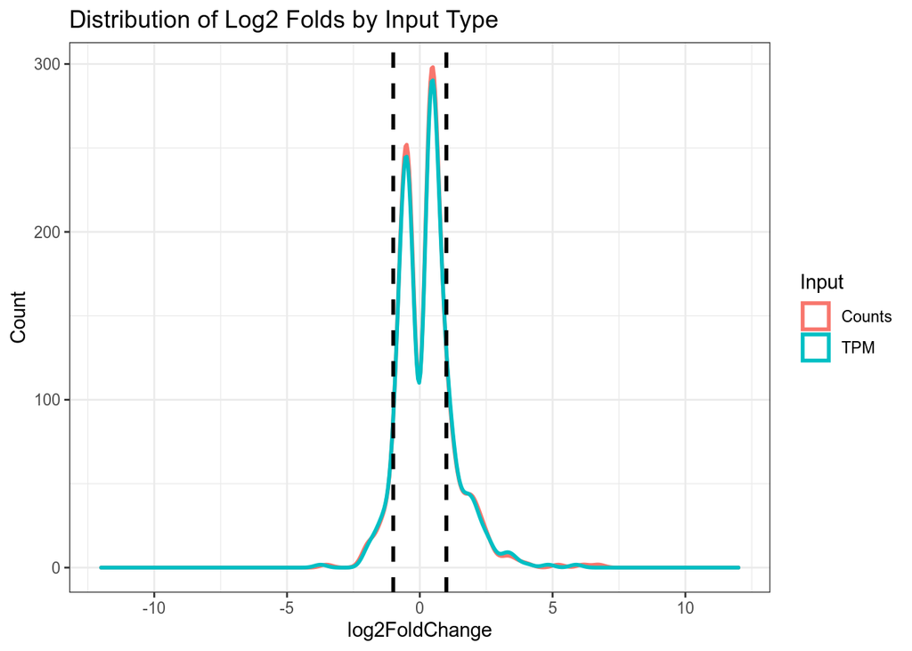

```r
# Initialize a lfc list
lfcplotList <- ddsList

# Create lfc distribution plots
for (i in shrinkage) {

    both.df <- rbind(all.resList[[i]][[TvC[1]]],
                     all.resList[[i]][[TvC[2]]])

    both.df <- both.df[both.df$FDR == "< 0.1",]

    lfcplotList[[i]] <- ggplot(both.df,  # Subset rows with FDR < alpha
                               aes(x=log2FoldChange, color=Input)) + geom_density(size=1, aes(y=..count..)) + theme_bw() + ylab("Count") + geom_vline(xintercept=c(mLog[1], mLog[2]), color="black", linetype="dashed", size=1) + ggtitle("Distribution of Log2 Folds by Input Type") + xlim(-12, 12)



}

# Print the lfc plots
lfcplotList
```

## Ranking DEGs

#### - **fdr.rank**: ranked by FDR

#### - **lfc.rank**: ranked by absolute fold change

#### - **up.lfc.rank**: ranked by magnitude of fold change increase

#### - **down.lfc.rank**: ranked by manitude of fold change decrease

```r
# Create a new list having DE table with FDR below alpha
fdr.rank <- all.resList
lfc.rank <- all.resList
up.lfc.rank <- all.resList
down.lfc.rank <- all.resList

# Set a function cleaning a data frame
filter.fdr.fn <- function(df) {as.data.table(df[df$FDR == FDRv[1],])}

# Set a function creating a column for the rank
Ranking.fn <- function(x) {mutate(x, Rank=1:nrow(x))}


for (i in shrinkage) {

    for (x in TvC) {

        rankdf <- all.resList[[i]][[x]]

        fdr.rank[[i]][[x]] <- filter.fdr.fn(rankdf) %>% arrange(padj) %>% Ranking.fn()

        lfc.rank[[i]][[x]] <- filter.fdr.fn(rankdf) %>% arrange(desc(abs(log2FoldChange))) %>% Ranking.fn()

        up.lfc.rank[[i]][[x]] <- filter.fdr.fn(rankdf) %>%
            arrange(desc(log2FoldChange)) %>%
            Ranking.fn()

        down.lfc.rank[[i]][[x]] <- filter.fdr.fn(rankdf) %>%
            arrange(log2FoldChange) %>%
            Ranking.fn()

    }
}

# Explore the ranking outputs
head(fdr.rank[[1]][[1]])
```

```
##       Gene   baseMean log2FoldChange     lfcSE     stat       pvalue
## 1:    CCN2  3782.1546       3.486643 0.1950104 17.87927 1.710657e-71
## 2:     F2R  2460.4827       1.954674 0.1235420 15.82194 2.196087e-56
## 3:   CDCP1  1500.9144       2.752287 0.1916214 14.36315 8.812579e-47
## 4:  STK38L 11846.6666       1.939965 0.1373091 14.12845 2.536811e-45
## 5: TM4SF18  1895.6825       2.030180 0.1457396 13.93019 4.152312e-44
## 6:   GPR87   526.0495       3.595677 0.2633221 13.65505 1.883633e-42
##            padj   FDR Input Rank
## 1: 6.249030e-68 < 0.1   TPM    1
## 2: 4.011153e-53 < 0.1   TPM    2
## 3: 1.073078e-43 < 0.1   TPM    3
## 4: 2.316742e-42 < 0.1   TPM    4
## 5: 3.033679e-41 < 0.1   TPM    5
## 6: 1.146819e-39 < 0.1   TPM    6
```

```r
head(fdr.rank[[1]][[2]])
```

```
##       Gene   baseMean log2FoldChange     lfcSE     stat       pvalue
## 1:    CCN2  3838.8131       3.485076 0.1956890 17.80925 5.990320e-71
## 2:     F2R  2498.1179       1.952867 0.1237315 15.78310 4.067010e-56
## 3:   CDCP1  1523.3025       2.749720 0.1920685 14.31635 1.729741e-46
## 4:  STK38L 12016.7778       1.938555 0.1380097 14.04651 8.092088e-45
## 5: TM4SF18  1919.1263       2.028913 0.1458347 13.91241 5.325183e-44
## 6:   GPR87   533.5471       3.593619 0.2631357 13.65690 1.836253e-42
##            padj   FDR  Input Rank
## 1: 2.188863e-67 < 0.1 Counts    1
## 2: 7.430427e-53 < 0.1 Counts    2
## 3: 2.106825e-43 < 0.1 Counts    3
## 4: 7.392122e-42 < 0.1 Counts    4
## 5: 3.891644e-41 < 0.1 Counts    5
## 6: 1.118278e-39 < 0.1 Counts    6
```

```r
head(lfc.rank[[1]][[1]])
```

```
##            Gene  baseMean log2FoldChange     lfcSE      stat       pvalue
## 1:    RPL36AP37 15.010762      20.722648 3.9097498  5.300249 1.156447e-07
## 2: TRIM39-RPP21 14.963658       7.357277 1.3588280  5.414428 6.148483e-08
## 3:        ALPK2 46.264341       6.562879 1.5079611  4.352154 1.348067e-05
## 4:      C5orf46  7.009990       6.266813 1.6281884  3.848948 1.186261e-04
## 5:       BPTFP1  6.033026      -6.053508 1.6148643 -3.748617 1.778121e-04
## 6:        MUC12 31.299509       5.963490 0.9954338  5.990845 2.087531e-09
##            padj   FDR Input Rank
## 1: 4.912212e-06 < 0.1   TPM    1
## 2: 2.739074e-06 < 0.1   TPM    2
## 3: 3.282993e-04 < 0.1   TPM    3
## 4: 2.155927e-03 < 0.1   TPM    4
## 5: 3.007166e-03 < 0.1   TPM    5
## 6: 1.229960e-07 < 0.1   TPM    6
```

```r
head(lfc.rank[[1]][[2]])
```

```
##            Gene  baseMean log2FoldChange     lfcSE      stat       pvalue
## 1:    RPL36AP37 15.154500      20.715593 3.9097649  5.298424 1.168063e-07
## 2:        ALPK2 44.935384       7.658726 1.3185732  5.808344 6.309395e-09
## 3: TRIM39-RPP21 15.294288       7.367963 1.3504996  5.455731 4.877170e-08
## 4:      C5orf46  7.111688       6.266180 1.6142688  3.881745 1.037095e-04
## 5:       BPTFP1  6.129028      -6.057848 1.5988793 -3.788809 1.513713e-04
## 6:        MUC12 19.797258       5.935466 0.9115626  6.511310 7.449834e-11
##            padj   FDR  Input Rank
## 1: 4.962910e-06 < 0.1 Counts    1
## 2: 3.440975e-07 < 0.1 Counts    2
## 3: 2.174383e-06 < 0.1 Counts    3
## 4: 1.876013e-03 < 0.1 Counts    4
## 5: 2.609012e-03 < 0.1 Counts    5
## 6: 5.917760e-09 < 0.1 Counts    6
```

```r
head(up.lfc.rank[[1]][[1]])
```

```
##            Gene  baseMean log2FoldChange     lfcSE     stat       pvalue
## 1:    RPL36AP37  15.01076      20.722648 3.9097498 5.300249 1.156447e-07
## 2: TRIM39-RPP21  14.96366       7.357277 1.3588280 5.414428 6.148483e-08
## 3:        ALPK2  46.26434       6.562879 1.5079611 4.352154 1.348067e-05
## 4:      C5orf46   7.00999       6.266813 1.6281884 3.848948 1.186261e-04
## 5:        MUC12  31.29951       5.963490 0.9954338 5.990845 2.087531e-09
## 6:         MMP7 134.20635       5.338582 1.1062628 4.825781 1.394554e-06
##            padj   FDR Input Rank
## 1: 4.912212e-06 < 0.1   TPM    1
## 2: 2.739074e-06 < 0.1   TPM    2
## 3: 3.282993e-04 < 0.1   TPM    3
## 4: 2.155927e-03 < 0.1   TPM    4
## 5: 1.229960e-07 < 0.1   TPM    5
## 6: 4.673676e-05 < 0.1   TPM    6
```

```r
head(up.lfc.rank[[1]][[2]])
```

```
##            Gene   baseMean log2FoldChange     lfcSE     stat       pvalue
## 1:    RPL36AP37  15.154500      20.715593 3.9097649 5.298424 1.168063e-07
## 2:        ALPK2  44.935384       7.658726 1.3185732 5.808344 6.309395e-09
## 3: TRIM39-RPP21  15.294288       7.367963 1.3504996 5.455731 4.877170e-08
## 4:      C5orf46   7.111688       6.266180 1.6142688 3.881745 1.037095e-04
## 5:        MUC12  19.797258       5.935466 0.9115626 6.511310 7.449834e-11
## 6:         MMP7 136.082046       5.333423 1.1050529 4.826396 1.390260e-06
##            padj   FDR  Input Rank
## 1: 4.962910e-06 < 0.1 Counts    1
## 2: 3.440975e-07 < 0.1 Counts    2
## 3: 2.174383e-06 < 0.1 Counts    3
## 4: 1.876013e-03 < 0.1 Counts    4
## 5: 5.917760e-09 < 0.1 Counts    5
## 6: 4.592975e-05 < 0.1 Counts    6
```

```r
head(down.lfc.rank[[1]][[1]])
```

```
##            Gene  baseMean log2FoldChange    lfcSE      stat       pvalue
## 1:       BPTFP1  6.033026      -6.053508 1.614864 -3.748617 1.778121e-04
## 2:   MROH7-TTC4 19.770937      -5.205907 1.040842 -5.001629 5.684777e-07
## 3:    TEN1-CDK3  5.483008      -4.149457 1.544679 -2.686291 7.225009e-03
## 4: LOC100422024  8.961759      -3.762518 1.098125 -3.426312 6.118378e-04
## 5:        CDKL4  8.951564      -3.716447 1.143806 -3.249193 1.157328e-03
## 6:        AGBL1  6.489977      -3.209238 1.179382 -2.721119 6.506139e-03
##            padj   FDR Input Rank
## 1: 3.007166e-03 < 0.1   TPM    1
## 2: 2.185946e-05 < 0.1   TPM    2
## 3: 6.012063e-02 < 0.1   TPM    3
## 4: 8.563385e-03 < 0.1   TPM    4
## 5: 1.423474e-02 < 0.1   TPM    5
## 6: 5.637809e-02 < 0.1   TPM    6
```

```r
head(down.lfc.rank[[1]][[2]])
```

```
##            Gene  baseMean log2FoldChange     lfcSE      stat       pvalue
## 1:       BPTFP1  6.129028      -6.057848 1.5988793 -3.788809 1.513713e-04
## 2:   MROH7-TTC4 20.243254      -4.777119 0.9648959 -4.950916 7.386496e-07
## 3:    TEN1-CDK3  5.565687      -4.225319 1.5371102 -2.748872 5.980078e-03
## 4: LOC100422024  9.095538      -3.770517 1.0848077 -3.475747 5.094331e-04
## 5:         AARD 15.249451      -3.415316 0.8619512 -3.962307 7.422891e-05
## 6:        CDKL4  8.565669      -3.402486 1.0772242 -3.158568 1.585461e-03
##            padj   FDR  Input Rank
## 1: 2.609012e-03 < 0.1 Counts    1
## 2: 2.726289e-05 < 0.1 Counts    2
## 3: 5.195368e-02 < 0.1 Counts    3
## 4: 7.243068e-03 < 0.1 Counts    4
## 5: 1.420065e-03 < 0.1 Counts    5
## 6: 1.821785e-02 < 0.1 Counts    6
```

## Calculating rank difference

```r
# Set a function rebuilding DE tables with gene ranks
rankdiff.fn <- function(List){

    # Select columns and join the data frames by gene
    full_join(List[[TvC[1]]][, .(Gene, Input, Rank, baseMean)],
              List[[TvC[2]]][, .(Gene, Input, Rank, baseMean)],
              by="Gene") %>%

    # Add columns assining gene expression levels, rank differences, and mean ranks
    mutate(logMeanExpression=log(baseMean.x+baseMean.y/2),
           RankDiff=Rank.x-Rank.y,
           MeanRank=(Rank.x+Rank.y)/2)
}

# Set a function adding Shrinkage column
add.shr.fn <- function(df, shr) {mutate(df, Shrinkage=shr)}

# Set a function rbinding multiple data frames
rbinds.fn <- function(List) {rbind(List[[1]],
                                   List[[2]],
                                   List[[3]],
                                   List[[4]])}



# Calculate and plot rank difference
for (i in shrinkage) {

    # Calculate rank difference
    fdr.rank[[i]] <- rankdiff.fn(fdr.rank[[i]]) %>% add.shr.fn(i)
    lfc.rank[[i]] <- rankdiff.fn(lfc.rank[[i]]) %>% add.shr.fn(i)
    up.lfc.rank[[i]] <- rankdiff.fn(up.lfc.rank[[i]]) %>% add.shr.fn(i)
    down.lfc.rank[[i]] <- rankdiff.fn(down.lfc.rank[[i]]) %>% add.shr.fn(i)

}

# Create combined data frames across the shrinkages
fdr.rank.df <- rbinds.fn(fdr.rank)
lfc.rank.df <- rbinds.fn(lfc.rank)
up.lfc.rank.df <- rbinds.fn(up.lfc.rank)
down.lfc.rank.df <- rbinds.fn(down.lfc.rank)



# Explore the ranking outputs
head(fdr.rank.df)
```

```
##       Gene Input.x Rank.x baseMean.x Input.y Rank.y baseMean.y
## 1:    CCN2     TPM      1  3782.1546  Counts      1  3838.8131
## 2:     F2R     TPM      2  2460.4827  Counts      2  2498.1179
## 3:   CDCP1     TPM      3  1500.9144  Counts      3  1523.3025
## 4:  STK38L     TPM      4 11846.6666  Counts      4 12016.7778
## 5: TM4SF18     TPM      5  1895.6825  Counts      5  1919.1263
## 6:   GPR87     TPM      6   526.0495  Counts      6   533.5471
##    logMeanExpression RankDiff MeanRank Shrinkage
## 1:          8.648495        0        1      None
## 2:          8.218664        0        2      None
## 3:          7.724255        0        3      None
## 4:          9.790042        0        4      None
## 5:          7.956913        0        5      None
## 6:          6.675600        0        6      None
```

```r
head(lfc.rank.df)
```

```
##            Gene Input.x Rank.x baseMean.x Input.y Rank.y baseMean.y
## 1:    RPL36AP37     TPM      1  15.010762  Counts      1  15.154500
## 2: TRIM39-RPP21     TPM      2  14.963658  Counts      3  15.294288
## 3:        ALPK2     TPM      3  46.264341  Counts      2  44.935384
## 4:      C5orf46     TPM      4   7.009990  Counts      4   7.111688
## 5:       BPTFP1     TPM      5   6.033026  Counts      5   6.129028
## 6:        MUC12     TPM      6  31.299509  Counts      6  19.797258
##    logMeanExpression RankDiff MeanRank Shrinkage
## 1:          3.117419        0      1.0      None
## 2:          3.118428       -1      2.5      None
## 3:          4.230215        1      2.5      None
## 4:          2.357626        0      4.0      None
## 5:          2.208004        0      5.0      None
## 6:          3.718393        0      6.0      None
```

```r
head(up.lfc.rank.df)
```

```
##            Gene Input.x Rank.x baseMean.x Input.y Rank.y baseMean.y
## 1:    RPL36AP37     TPM      1   15.01076  Counts      1  15.154500
## 2: TRIM39-RPP21     TPM      2   14.96366  Counts      3  15.294288
## 3:        ALPK2     TPM      3   46.26434  Counts      2  44.935384
## 4:      C5orf46     TPM      4    7.00999  Counts      4   7.111688
## 5:        MUC12     TPM      5   31.29951  Counts      5  19.797258
## 6:         MMP7     TPM      6  134.20635  Counts      6 136.082046
##    logMeanExpression RankDiff MeanRank Shrinkage
## 1:          3.117419        0      1.0      None
## 2:          3.118428       -1      2.5      None
## 3:          4.230215        1      2.5      None
## 4:          2.357626        0      4.0      None
## 5:          3.718393        0      5.0      None
## 6:          5.309492        0      6.0      None
```

```r
head(down.lfc.rank.df)
```

```
##            Gene Input.x Rank.x baseMean.x Input.y Rank.y baseMean.y
## 1:       BPTFP1     TPM      1   6.033026  Counts      1   6.129028
## 2:   MROH7-TTC4     TPM      2  19.770937  Counts      2  20.243254
## 3:    TEN1-CDK3     TPM      3   5.483008  Counts      3   5.565687
## 4: LOC100422024     TPM      4   8.961759  Counts      4   9.095538
## 5:        CDKL4     TPM      5   8.951564  Counts      6   8.565669
## 6:        AGBL1     TPM      6   6.489977    <NA>     NA         NA
##    logMeanExpression RankDiff MeanRank Shrinkage
## 1:          2.208004        0      1.0      None
## 2:          3.397610        0      2.0      None
## 3:          2.112133        0      3.0      None
## 4:          2.603395        0      4.0      None
## 5:          2.582819       -1      5.5      None
## 6:                NA       NA       NA      None
```

## Visualizing DEG ranks I: TPM- vs Counts-input

#### - **x-axis**: rank with TPM input

#### - **y-axis**: rank with Counts input

#### - Black diagonal lines: rank with TPM = rank with Counts

#### - Dot color: gene expression level (log-baseMean)

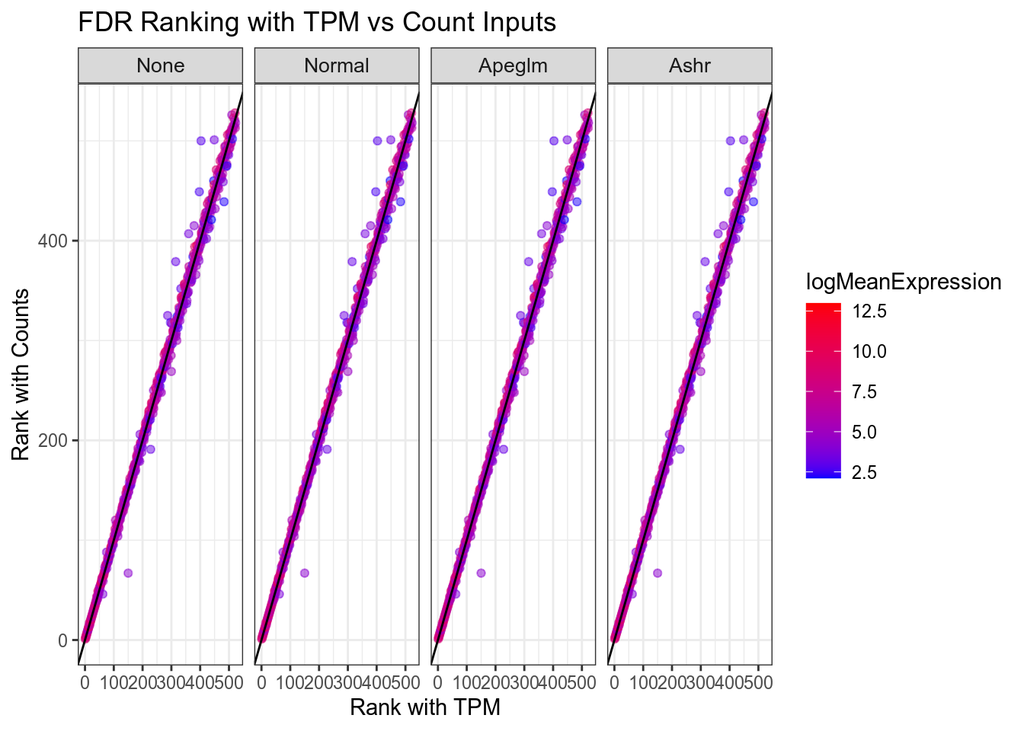

```r
# Set a function plotting gene ranks between TPM- (x-axis) and Counts-Inputs (y-axis)
ranking.plot.fn <- function(df, rankedby) {

    df$Shrinkage <- factor(df$Shrinkage, levels=shrinkage)

    ggplot(df,
           aes(x=Rank.x, y=Rank.y, color=logMeanExpression)) + geom_point(alpha=0.5) + facet_grid(~Shrinkage) + theme_bw() + theme(strip.text.x=element_text(size=10)) + xlab("Rank with TPM") + ylab("Rank with Counts") + geom_abline(slope=1, color="black", size=0.5) + ggtitle(paste(rankedby, "Ranking with TPM vs Count Inputs")) + scale_color_gradient(low="blue", high="red")
}

# Print output plots
ranking.plot.fn(fdr.rank.df, "FDR")
```

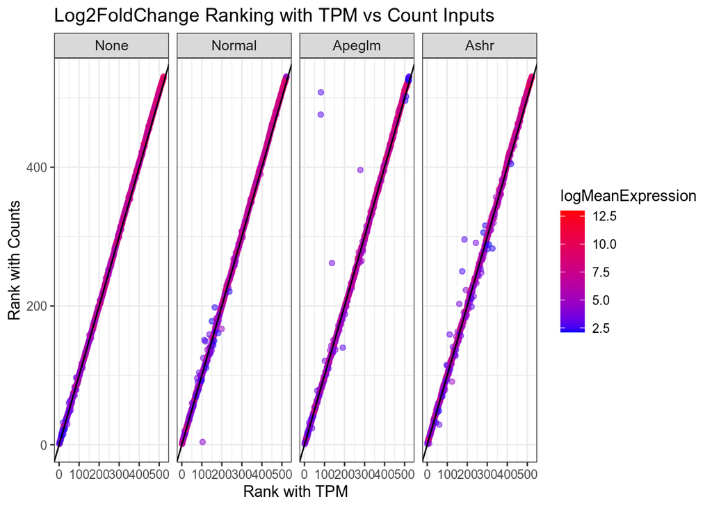

```r
ranking.plot.fn(lfc.rank.df, "Log2FoldChange")
```

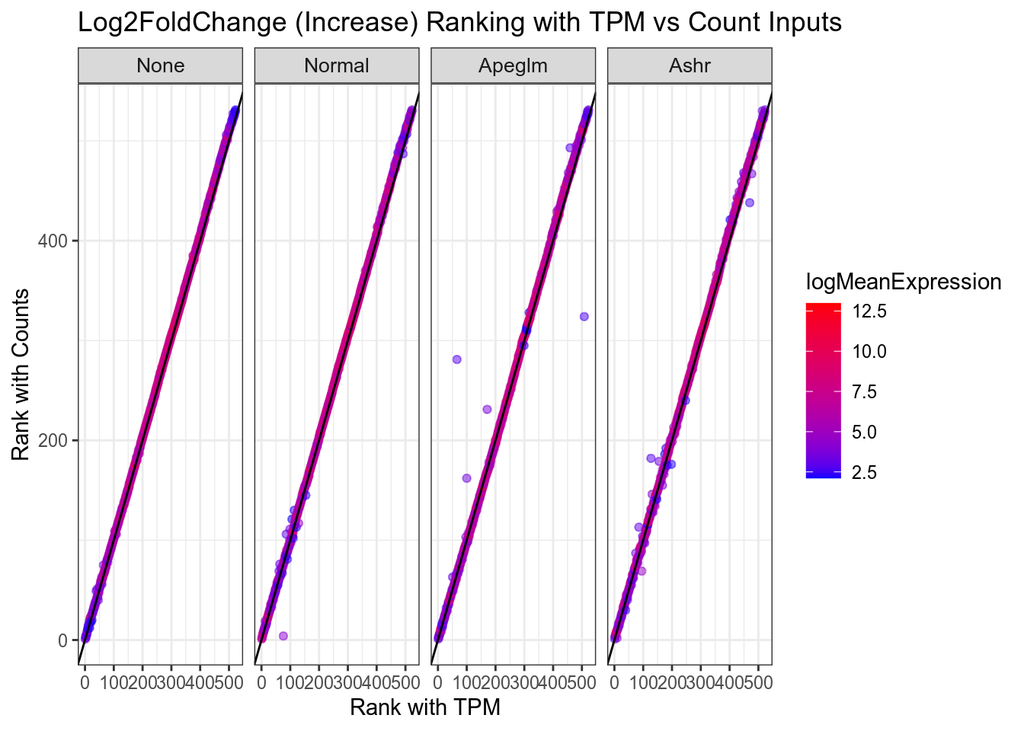

```r
ranking.plot.fn(up.lfc.rank.df, "Log2FoldChange (Increase)")
```

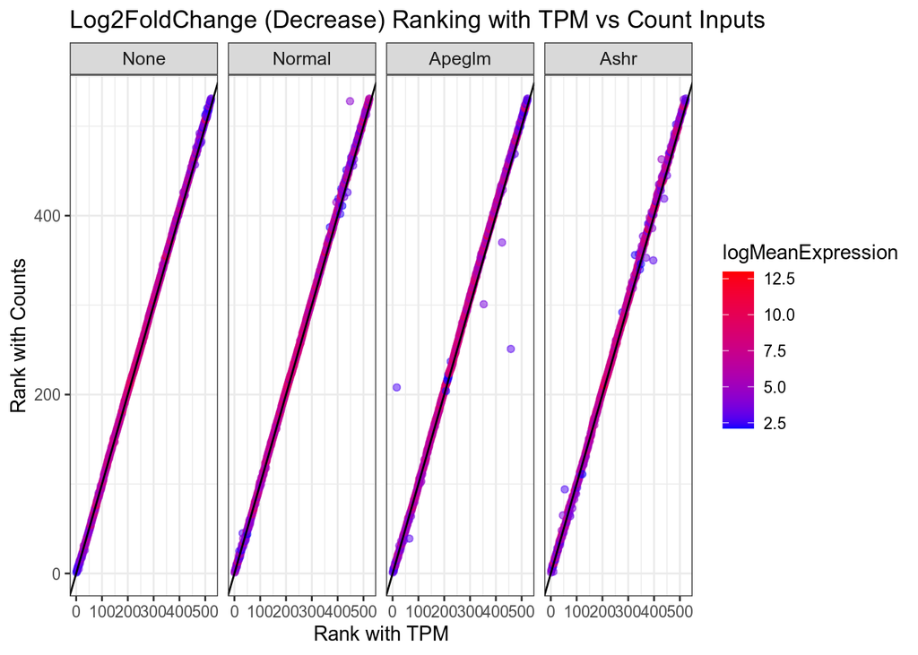

```r
ranking.plot.fn(down.lfc.rank.df, "Log2FoldChange (Decrease)")
```

## Visualizing DEG ranks II: Rank difference

#### - **x-axis**: expression level (log-baseMean)

#### - **y-axis**: rank difference (rank with TPM - rank with Counts)

#### - Black horizontal lines: rank with TPM = rank with Counts

#### - Dot color: average rank

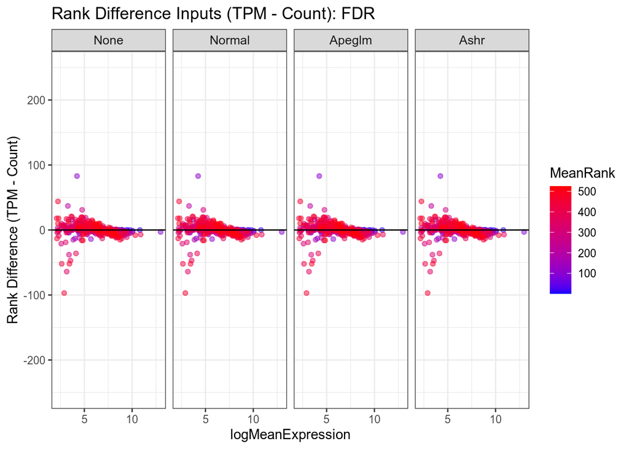

```r
# Set a function plotting the rank difference over the gene expression level
rankdiff.plot.fn <- function(df, rankedby) {

    df$Shrinkage <- factor(df$Shrinkage, levels=shrinkage)

    ggplot(df, aes(x=logMeanExpression, y=RankDiff, color=MeanRank)) +
        geom_point(alpha=0.5) +
        theme_bw() +
        facet_grid(~Shrinkage) +
        theme(strip.text.x=element_text(size=10)) +
        ylab("Rank Difference (TPM - Count)") +
        ggtitle(paste("Rank Difference Inputs (TPM - Count):", rankedby)) +
        geom_hline(yintercept=0, color="black", size=0.5) + scale_color_gradient(low="blue", high="red") +
        ylim(-250, 250)
}

# Print output plots
rankdiff.plot.fn(fdr.rank.df, "FDR")
```

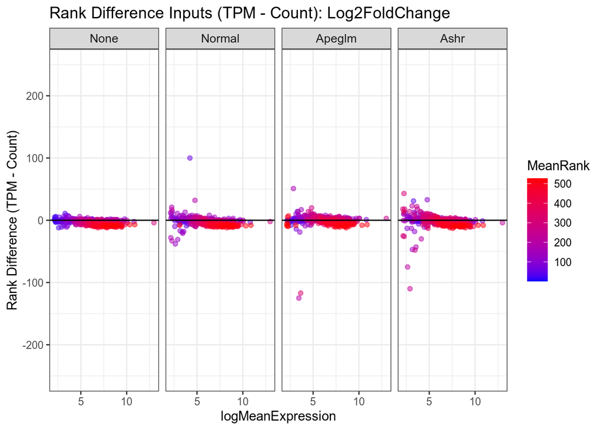

```r
rankdiff.plot.fn(lfc.rank.df, "Log2FoldChange")
```

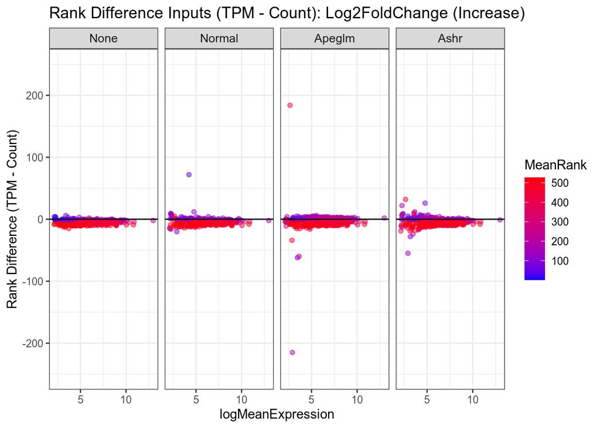

```r
rankdiff.plot.fn(up.lfc.rank.df, "Log2FoldChange (Increase)")
```

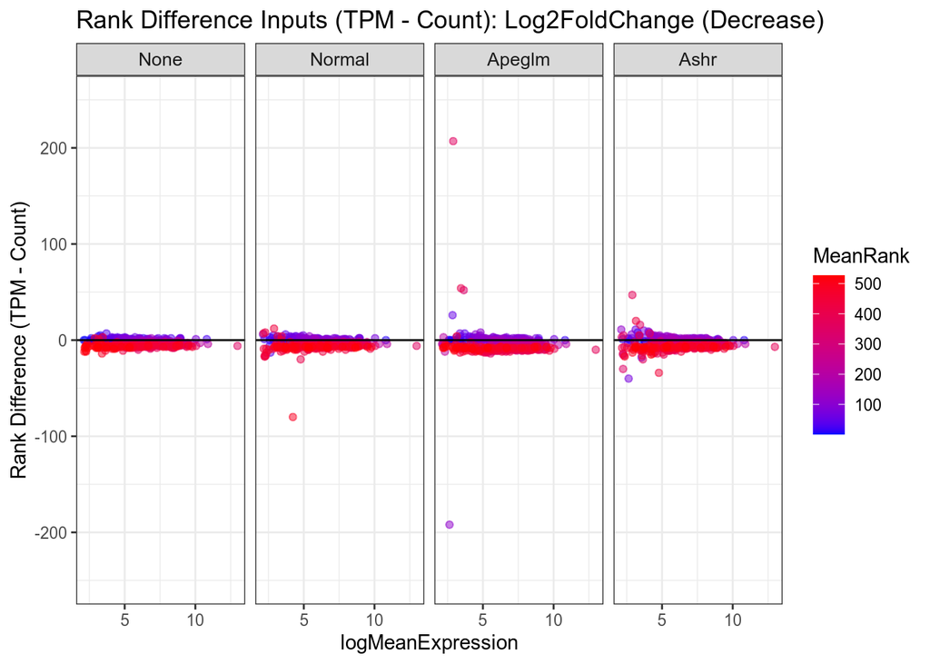

```r
rankdiff.plot.fn(down.lfc.rank.df, "Log2FoldChange (Decrease)")
```

## Summarizing up/down DEGs with an upset plot

- Calculate the number of genes

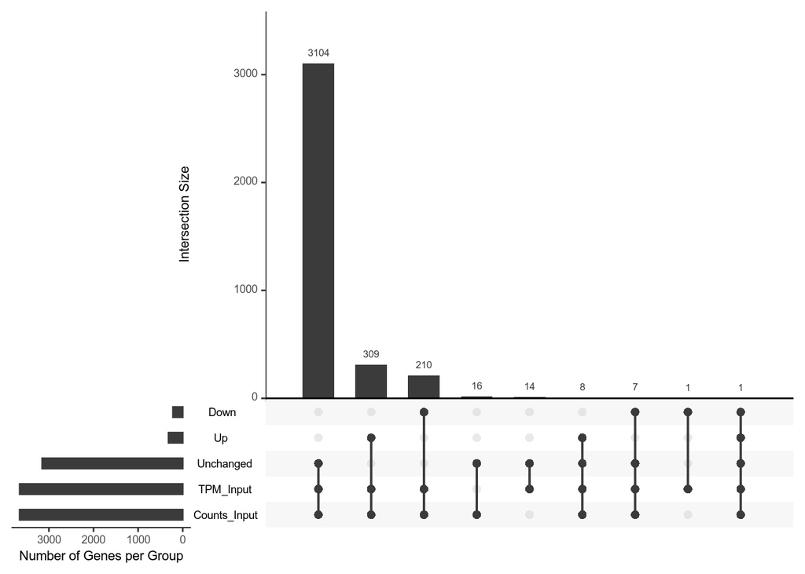

```r
# Set a function cleaning data to generate upset plots
upset.input.fn <- function(df) {

    df <- df %>%

        # Filter genes with valid padj
        filter(!is.na(padj)) %>%

        mutate(Up=ifelse(FDR == FDRv[1] & log2FoldChange > 0, Gene, ""), # What are upregulated genes?

               Down=ifelse(FDR == FDRv[1] & log2FoldChange < 0, Gene, ""),  # What are downregulated genes?

               Unchanged=ifelse(FDR == FDRv[2], Gene, ""),   # What are unchanged genes?

               TPM_Input=ifelse(Input == "TPM", Gene, ""),   # What are the genes from TPM input?

               Counts_Input=ifelse(Input == "Counts", Gene, ""))   # What are the genes from Counts input?

    # Create a list storing groups of interest
    upsetInput <- list(Up=df$Up,
                       Down=df$Down,
                       Unchanged=df$Unchanged,
                       TPM_Input=df$TPM,
                       Counts_Input=df$Counts)

    return(upsetInput)

}

# Create an input list from unshrunken DE results
# (DEGs are determined by FDR which is constant with or without shrinkage)
upsetList <- upset.input.fn(rbind(all.resList[[shrinkage[1]]][[TvC[1]]],
                                  all.resList[[shrinkage[1]]][[TvC[2]]]))


# Create the upset plot
upset(fromList(upsetList),
      sets.x.label="Number of Genes per Group",
      order.by="freq")
```